# DATA621 Final Project

IvanTikhonov, Seung Min Song, Alice Firedman

## Abstract

This study investigates the external factors affecting students’ academic performance in secondary schools’ math and Portuguese language courses. Using a quantitative dataset obtained through a survey, the study analyzes various external variables, such as students’ health, social and demographic factors, study habits, and other relevant factors to understand their impact on academic performance.

## Introduction

As a graduate student who is planning to raise a child, this study may be relevant to you as it explores the external factors that have an impact on students’ grades. By analyzing the various external variables that can influence academic performance, this study provides valuable insights that can help parents, educators, and policymakers to better support students’ success in school. Specifically, this study looks at factors such as students’ health, social and demographic factors, study habits, and other relevant factors that can have an impact on their academic performance.

Understanding the external factors that can affect a student’s academic performance can be helpful in creating a supportive home environment and developing effective strategies to help your child succeed in school. This study’s findings could also be useful for parents and educators to monitor and provide proper guidelines for external factors that may affect students’ academic performance, such as romantic relationships, drinking habits, and how they use their free time. By gaining a deeper understanding of how these factors impact students’ grades, parents and educators can work to create a more supportive environment for students and help them develop healthy habits that promote academic success.

In the wider educational industry, the findings of this study can provide insights into how to better support students’ academic success and enhance their overall educational experience. Educators and policymakers can use this research to identify areas where they can improve educational outcomes, such as implementing programs to support students’ health or providing resources to help students develop effective study habits.

## Key Words

- external factors
- academic performance
- Weighted Least Square Regression
- multiple linear regression
- health
- internet access
- study habits
- educational outcomes

## Literature review

- https://www.researchgate.net/publication/366929441_Application_of_Multiple_Linear_Regression_in_Identifying_Contributing_Factors_in_Students%27_Academic_Achievement

Title: Application of Multiple Linear Regressionin Identifying Contributing Factors in Students’Academic Achievement

Author: Dg Siti Nurisya Sahirah Binti Ag Isha and Siti Rahayu Binti Mohd Hashim

Mathematics With Economics Programme, Faculty of Science and Natural Resources,Universiti Malaysia Sabah, 88400 Kota Kinabalu, Sabah, Malaysia

This study aimed to identify significant factors that contribute to students’ academic success by analyzing internal and external factors. The study involved 327 final-year undergraduate students and found that self-esteem, intelligence, and maternal education were significant factors affecting students’ achievement. The government, educators, parents, and university administration should collaborate to establish methods or programs that focus on these three factors to improve students’ academic performance. For future research, it is recommended to employ structural equation modelling and consider additional variables such as study habits and time management.

**Data Source**

Downloaded the csv data table from the link below:

- https://www.kaggle.com/datasets/uciml/student-alcohol-consumption

**Data collection**

- student-mat.csv
- student-por.csv

**Libraries**

## Data Exploration

Include:

- Summary statistics means, medians, quartiles,
- Missing value information
- EDA
  - The dataframe df_mat contains 395 entries (rows) with 33 columns.
  - The dataset df_por contains 649 entries (rows) with 33 columns.
  - The data types of the columns include integers (int64) and objects (object).
  - The columns represent various features of the student dataset such as personal and family characteristics, academic performance, and social activities.
  - Some of the columns include: **school**, **sex**, **age**, **address**, **family size**, **parents’ education**, **mother and father’s occupation**, **travel time**, **study time**, **number of failures**, **support received from school**, **family**, **extra-curricular**, **activities**, **health**, and **academic grades**.

```r
df_mat <- read.csv("https://raw.githubusercontent.com/IvanGrozny88/DATA621-Final-Project/main/student-mat.csv")

df_por <- read.csv("https://raw.githubusercontent.com/IvanGrozny88/DATA621-Final-Project/main/student-por.csv")
summary(df_mat)
```

```
##     school              sex                 age         address
##  Length:395         Length:395         Min.   :15.0   Length:395
##  Class :character   Class :character   1st Qu.:16.0   Class :character
##  Mode  :character   Mode  :character   Median :17.0   Mode  :character
##                                        Mean   :16.7
##                                        3rd Qu.:18.0
##                                        Max.   :22.0
##    famsize            Pstatus               Medu            Fedu
##  Length:395         Length:395         Min.   :0.000   Min.   :0.000
##  Class :character   Class :character   1st Qu.:2.000   1st Qu.:2.000
##  Mode  :character   Mode  :character   Median :3.000   Median :2.000
##                                        Mean   :2.749   Mean   :2.522
##                                        3rd Qu.:4.000   3rd Qu.:3.000
##                                        Max.   :4.000   Max.   :4.000
##      Mjob               Fjob              reason            guardian
##  Length:395         Length:395         Length:395         Length:395
##  Class :character   Class :character   Class :character   Class :character
##  Mode  :character   Mode  :character   Mode  :character   Mode  :character
##
##
##
##    traveltime      studytime        failures       schoolsup
##  Min.   :1.000   Min.   :1.000   Min.   :0.0000   Length:395
##  1st Qu.:1.000   1st Qu.:1.000   1st Qu.:0.0000   Class :character
##  Median :1.000   Median :2.000   Median :0.0000   Mode  :character
##  Mean   :1.448   Mean   :2.035   Mean   :0.3342
##  3rd Qu.:2.000   3rd Qu.:2.000   3rd Qu.:0.0000
##  Max.   :4.000   Max.   :4.000   Max.   :3.0000
##     famsup              paid            activities          nursery
##  Length:395         Length:395         Length:395         Length:395
##  Class :character   Class :character   Class :character   Class :character
##  Mode  :character   Mode  :character   Mode  :character   Mode  :character
##
##
##
##     higher            internet           romantic             famrel
##  Length:395         Length:395         Length:395         Min.   :1.000
##  Class :character   Class :character   Class :character   1st Qu.:4.000
##  Mode  :character   Mode  :character   Mode  :character   Median :4.000
##                                                           Mean   :3.944
```

[output cut: 8 more lines]

```
##  Max.   :5.000   Max.   :5.000   Max.   :5.000   Max.   :5.000
##      health         absences            G1              G2
##  Min.   :1.000   Min.   : 0.000   Min.   : 3.00   Min.   : 0.00
##  1st Qu.:3.000   1st Qu.: 0.000   1st Qu.: 8.00   1st Qu.: 9.00
##  Median :4.000   Median : 4.000   Median :11.00   Median :11.00
##  Mean   :3.554   Mean   : 5.709   Mean   :10.91   Mean   :10.71
##  3rd Qu.:5.000   3rd Qu.: 8.000   3rd Qu.:13.00   3rd Qu.:13.00
##  Max.   :5.000   Max.   :75.000   Max.   :19.00   Max.   :19.00
##        G3
##  Min.   : 0.00
##  1st Qu.: 8.00
##  Median :11.00
##  Mean   :10.42
##  3rd Qu.:14.00
##  Max.   :20.00
```

```r
summary(df_por)
```

```
##     school              sex                 age          address
##  Length:649         Length:649         Min.   :15.00   Length:649
##  Class :character   Class :character   1st Qu.:16.00   Class :character
##  Mode  :character   Mode  :character   Median :17.00   Mode  :character
##                                        Mean   :16.74
##                                        3rd Qu.:18.00
##                                        Max.   :22.00
##    famsize            Pstatus               Medu            Fedu
##  Length:649         Length:649         Min.   :0.000   Min.   :0.000
##  Class :character   Class :character   1st Qu.:2.000   1st Qu.:1.000
##  Mode  :character   Mode  :character   Median :2.000   Median :2.000
##                                        Mean   :2.515   Mean   :2.307
##                                        3rd Qu.:4.000   3rd Qu.:3.000
##                                        Max.   :4.000   Max.   :4.000
##      Mjob               Fjob              reason            guardian
##  Length:649         Length:649         Length:649         Length:649
##  Class :character   Class :character   Class :character   Class :character
##  Mode  :character   Mode  :character   Mode  :character   Mode  :character
##
##
##
##    traveltime      studytime        failures       schoolsup
##  Min.   :1.000   Min.   :1.000   Min.   :0.0000   Length:649
##  1st Qu.:1.000   1st Qu.:1.000   1st Qu.:0.0000   Class :character
##  Median :1.000   Median :2.000   Median :0.0000   Mode  :character
##  Mean   :1.569   Mean   :1.931   Mean   :0.2219
##  3rd Qu.:2.000   3rd Qu.:2.000   3rd Qu.:0.0000
##  Max.   :4.000   Max.   :4.000   Max.   :3.0000
##     famsup              paid            activities          nursery
##  Length:649         Length:649         Length:649         Length:649
##  Class :character   Class :character   Class :character   Class :character
##  Mode  :character   Mode  :character   Mode  :character   Mode  :character
##
##
##
##     higher            internet           romantic             famrel
##  Length:649         Length:649         Length:649         Min.   :1.000
##  Class :character   Class :character   Class :character   1st Qu.:4.000
##  Mode  :character   Mode  :character   Mode  :character   Median :4.000
##                                                           Mean   :3.931
##                                                           3rd Qu.:5.000
##                                                           Max.   :5.000
##     freetime        goout            Dalc            Walc          health
##  Min.   :1.00   Min.   :1.000   Min.   :1.000   Min.   :1.00   Min.   :1.000
##  1st Qu.:3.00   1st Qu.:2.000   1st Qu.:1.000   1st Qu.:1.00   1st Qu.:2.000
##  Median :3.00   Median :3.000   Median :1.000   Median :2.00   Median :4.000
##  Mean   :3.18   Mean   :3.185   Mean   :1.502   Mean   :2.28   Mean   :3.536
##  3rd Qu.:4.00   3rd Qu.:4.000   3rd Qu.:2.000   3rd Qu.:3.00   3rd Qu.:5.000
##  Max.   :5.00   Max.   :5.000   Max.   :5.000   Max.   :5.00   Max.   :5.000
##     absences            G1             G2              G3
##  Min.   : 0.000   Min.   : 0.0   Min.   : 0.00   Min.   : 0.00
##  1st Qu.: 0.000   1st Qu.:10.0   1st Qu.:10.00   1st Qu.:10.00
##  Median : 2.000   Median :11.0   Median :11.00   Median :12.00
##  Mean   : 3.659   Mean   :11.4   Mean   :11.57   Mean   :11.91
##  3rd Qu.: 6.000   3rd Qu.:13.0   3rd Qu.:13.00   3rd Qu.:14.00
##  Max.   :32.000   Max.   :19.0   Max.   :19.00   Max.   :19.00
```

### Basic Plots

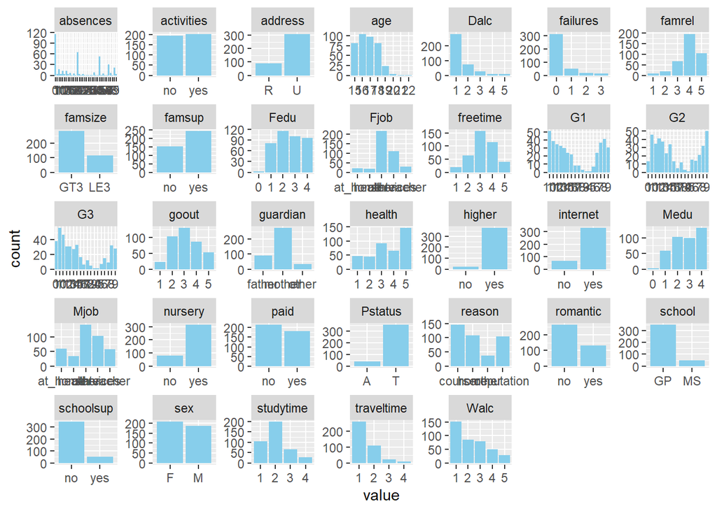

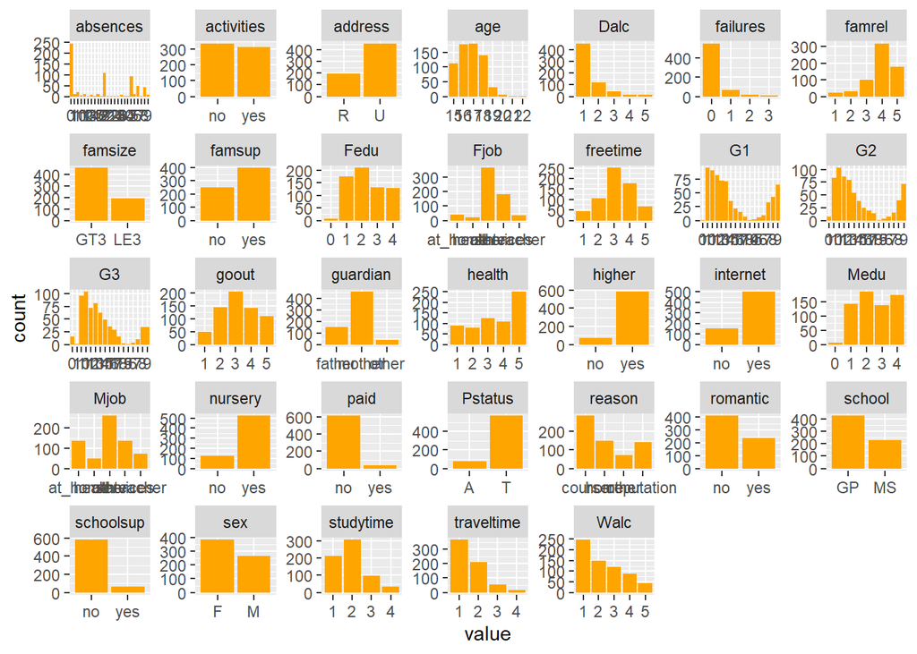

```r
#mat <- as.data.frame(mat)
por_new <- df_por %>% gather(key = 'key', value = 'value')
por_new %>% gather() %>% ggplot(aes(x= value)) + geom_histogram(stat = "count", fill = "orange") + facet_wrap(~key, scales = 'free', ncol=7)
```

### Correlation

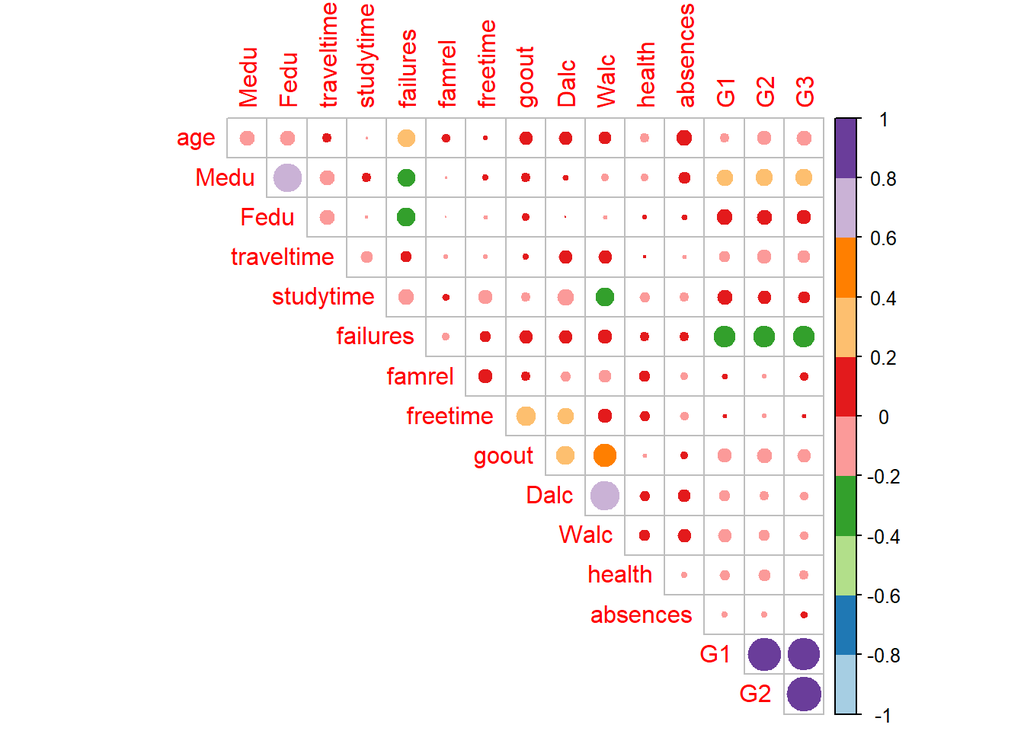

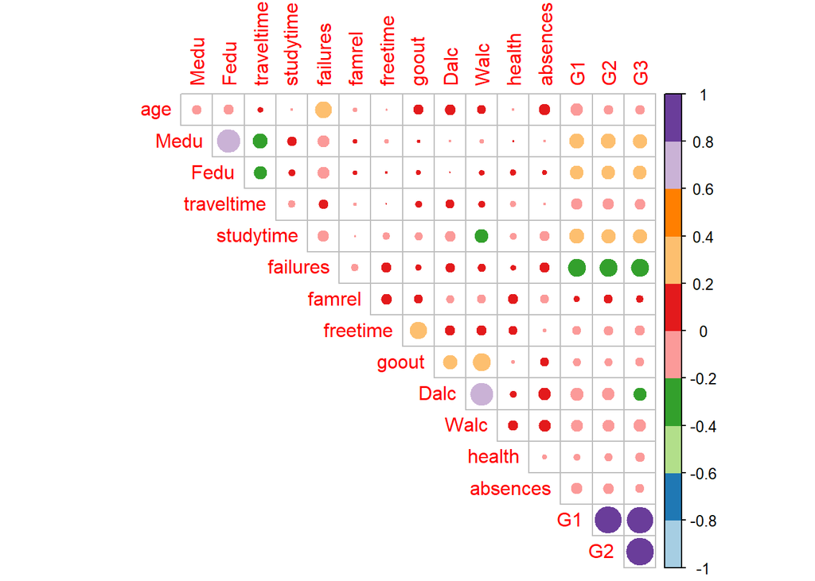

```r
corrplot(cor(df_por[,sapply(df_por, is.numeric)], use = "complete.obs"), type="upper", diag = FALSE, col=brewer.pal(n=10, name="Paired"))
```

### Missing values

Both dataset is complete with no missing values.

```
## [1] 0
```

```
## [1] 0
```

## Data Preparation

Include:

- Renaming columns
- Adding new columns
- Merging datasets
- Replacing binary values
- Remove rows

### Renaming columns

```r
# Rename columns in df_mat
colnames(df_mat)[colnames(df_mat) == "famsup"] <- "famEdsup"
colnames(df_mat)[colnames(df_mat) == "Dacl"] <- "dayAlc"
colnames(df_mat)[colnames(df_mat) == "Walc"] <- "weekAlc"
colnames(df_mat)[colnames(df_mat) == "goout"] <- "friendtime"

# Rename columns in df_por
colnames(df_por)[colnames(df_por) == "famsup"] <- "famEdsup"
colnames(df_por)[colnames(df_por) == "Dacl"] <- "dayAlc"
colnames(df_por)[colnames(df_por) == "Walc"] <- "weekAlc"
colnames(df_por)[colnames(df_por) == "goout"] <- "friendtime"
```

### Adding new columns

Use the Mutate() method to create a new column named **G1G2avg** and **G1G2avg** for future analysis.

```r
# create a new column named 'G1G2avg' with the value 'mat' and 'por'
df_mat <- df_mat %>% mutate(G1G2avg = (G1 + G2)/2)
print(head(df_mat))
```

```
##   school sex age address famsize Pstatus Medu Fedu     Mjob     Fjob     reason
## 1     GP   F  18       U     GT3       A    4    4  at_home  teacher     course
## 2     GP   F  17       U     GT3       T    1    1  at_home    other     course
## 3     GP   F  15       U     LE3       T    1    1  at_home    other      other
## 4     GP   F  15       U     GT3       T    4    2   health services       home
## 5     GP   F  16       U     GT3       T    3    3    other    other       home
## 6     GP   M  16       U     LE3       T    4    3 services    other reputation
##   guardian traveltime studytime failures schoolsup famEdsup paid activities
## 1   mother          2         2        0       yes       no   no         no
## 2   father          1         2        0        no      yes   no         no
## 3   mother          1         2        3       yes       no  yes         no
## 4   mother          1         3        0        no      yes  yes        yes
## 5   father          1         2        0        no      yes  yes         no
## 6   mother          1         2        0        no      yes  yes        yes
##   nursery higher internet romantic famrel freetime friendtime Dalc weekAlc
## 1     yes    yes       no       no      4        3          4    1       1
## 2      no    yes      yes       no      5        3          3    1       1
## 3     yes    yes      yes       no      4        3          2    2       3
## 4     yes    yes      yes      yes      3        2          2    1       1
## 5     yes    yes       no       no      4        3          2    1       2
## 6     yes    yes      yes       no      5        4          2    1       2
##   health absences G1 G2 G3 G1G2avg
## 1      3        6  5  6  6     5.5
## 2      3        4  5  5  6     5.0
## 3      3       10  7  8 10     7.5
## 4      5        2 15 14 15    14.5
## 5      5        4  6 10 10     8.0
## 6      5       10 15 15 15    15.0
```

```r
df_por <- df_por %>% mutate(G1G2avg = (G1 + G2)/2)
print(head(df_por))
```

```
##   school sex age address famsize Pstatus Medu Fedu     Mjob     Fjob     reason
## 1     GP   F  18       U     GT3       A    4    4  at_home  teacher     course
## 2     GP   F  17       U     GT3       T    1    1  at_home    other     course
## 3     GP   F  15       U     LE3       T    1    1  at_home    other      other
## 4     GP   F  15       U     GT3       T    4    2   health services       home
## 5     GP   F  16       U     GT3       T    3    3    other    other       home
## 6     GP   M  16       U     LE3       T    4    3 services    other reputation
##   guardian traveltime studytime failures schoolsup famEdsup paid activities
## 1   mother          2         2        0       yes       no   no         no
## 2   father          1         2        0        no      yes   no         no
## 3   mother          1         2        0       yes       no   no         no
## 4   mother          1         3        0        no      yes   no        yes
## 5   father          1         2        0        no      yes   no         no
## 6   mother          1         2        0        no      yes   no        yes
##   nursery higher internet romantic famrel freetime friendtime Dalc weekAlc
## 1     yes    yes       no       no      4        3          4    1       1
## 2      no    yes      yes       no      5        3          3    1       1
## 3     yes    yes      yes       no      4        3          2    2       3
## 4     yes    yes      yes      yes      3        2          2    1       1
## 5     yes    yes       no       no      4        3          2    1       2
## 6     yes    yes      yes       no      5        4          2    1       2
##   health absences G1 G2 G3 G1G2avg
## 1      3        4  0 11 11     5.5
## 2      3        2  9 11 11    10.0
## 3      3        6 12 13 12    12.5
## 4      5        0 14 14 14    14.0
## 5      5        0 11 13 13    12.0
## 6      5        6 12 12 13    12.0
```

```r
# create a new column named 'G1G2G3avg' with the value 'mat' and 'por'
df_mat <- df_mat %>% mutate(G1G2G3avg = round((G1 + G2 + G3)/3, 1))
print(head(df_mat))
```

```
##   school sex age address famsize Pstatus Medu Fedu     Mjob     Fjob     reason
## 1     GP   F  18       U     GT3       A    4    4  at_home  teacher     course
## 2     GP   F  17       U     GT3       T    1    1  at_home    other     course
## 3     GP   F  15       U     LE3       T    1    1  at_home    other      other
## 4     GP   F  15       U     GT3       T    4    2   health services       home
## 5     GP   F  16       U     GT3       T    3    3    other    other       home
## 6     GP   M  16       U     LE3       T    4    3 services    other reputation
##   guardian traveltime studytime failures schoolsup famEdsup paid activities
## 1   mother          2         2        0       yes       no   no         no
## 2   father          1         2        0        no      yes   no         no
## 3   mother          1         2        3       yes       no  yes         no
## 4   mother          1         3        0        no      yes  yes        yes
## 5   father          1         2        0        no      yes  yes         no
## 6   mother          1         2        0        no      yes  yes        yes
##   nursery higher internet romantic famrel freetime friendtime Dalc weekAlc
## 1     yes    yes       no       no      4        3          4    1       1
## 2      no    yes      yes       no      5        3          3    1       1
## 3     yes    yes      yes       no      4        3          2    2       3
## 4     yes    yes      yes      yes      3        2          2    1       1
## 5     yes    yes       no       no      4        3          2    1       2
## 6     yes    yes      yes       no      5        4          2    1       2
##   health absences G1 G2 G3 G1G2avg G1G2G3avg
## 1      3        6  5  6  6     5.5       5.7
## 2      3        4  5  5  6     5.0       5.3
## 3      3       10  7  8 10     7.5       8.3
## 4      5        2 15 14 15    14.5      14.7
## 5      5        4  6 10 10     8.0       8.7
## 6      5       10 15 15 15    15.0      15.0
```

```r
df_por <- df_por %>% mutate(G1G2G3avg = round((G1 + G2 + G3)/3, 1))
print(head(df_por))
```

```
##   school sex age address famsize Pstatus Medu Fedu     Mjob     Fjob     reason
## 1     GP   F  18       U     GT3       A    4    4  at_home  teacher     course
## 2     GP   F  17       U     GT3       T    1    1  at_home    other     course
## 3     GP   F  15       U     LE3       T    1    1  at_home    other      other
## 4     GP   F  15       U     GT3       T    4    2   health services       home
## 5     GP   F  16       U     GT3       T    3    3    other    other       home
## 6     GP   M  16       U     LE3       T    4    3 services    other reputation
##   guardian traveltime studytime failures schoolsup famEdsup paid activities
## 1   mother          2         2        0       yes       no   no         no
## 2   father          1         2        0        no      yes   no         no
## 3   mother          1         2        0       yes       no   no         no
## 4   mother          1         3        0        no      yes   no        yes
## 5   father          1         2        0        no      yes   no         no
## 6   mother          1         2        0        no      yes   no        yes
##   nursery higher internet romantic famrel freetime friendtime Dalc weekAlc
## 1     yes    yes       no       no      4        3          4    1       1
## 2      no    yes      yes       no      5        3          3    1       1
## 3     yes    yes      yes       no      4        3          2    2       3
## 4     yes    yes      yes      yes      3        2          2    1       1
## 5     yes    yes       no       no      4        3          2    1       2
## 6     yes    yes      yes       no      5        4          2    1       2
##   health absences G1 G2 G3 G1G2avg G1G2G3avg
## 1      3        4  0 11 11     5.5       7.3
## 2      3        2  9 11 11    10.0      10.3
## 3      3        6 12 13 12    12.5      12.3
## 4      5        0 14 14 14    14.0      14.0
## 5      5        0 11 13 13    12.0      12.3
## 6      5        6 12 12 13    12.0      12.3
```

```r
# create a new column named 'class' with the value 'mat' and 'por'
df_mat$class <- 'mat'
df_por$class <- 'por'

# Print total G1G2G3avg
total_avg <- mean(df_mat$G1G2G3avg)
total_avg2 <- mean(df_por$G1G2G3avg)
print(total_avg)
```

```
## [1] 10.67747
```

```r
print(total_avg2)
```

```
## [1] 11.62558
```

### Merging datasets

Combine the two dataset and reset the index for future analysis.

```r
df_student <- rbind(df_mat, df_por)

# Reset the index
row.names(df_student) <- NULL
head(df_student)
```

```
##   school sex age address famsize Pstatus Medu Fedu     Mjob     Fjob     reason
## 1     GP   F  18       U     GT3       A    4    4  at_home  teacher     course
## 2     GP   F  17       U     GT3       T    1    1  at_home    other     course
## 3     GP   F  15       U     LE3       T    1    1  at_home    other      other
## 4     GP   F  15       U     GT3       T    4    2   health services       home
## 5     GP   F  16       U     GT3       T    3    3    other    other       home
## 6     GP   M  16       U     LE3       T    4    3 services    other reputation
##   guardian traveltime studytime failures schoolsup famEdsup paid activities
## 1   mother          2         2        0       yes       no   no         no
## 2   father          1         2        0        no      yes   no         no
## 3   mother          1         2        3       yes       no  yes         no
## 4   mother          1         3        0        no      yes  yes        yes
## 5   father          1         2        0        no      yes  yes         no
## 6   mother          1         2        0        no      yes  yes        yes
##   nursery higher internet romantic famrel freetime friendtime Dalc weekAlc
## 1     yes    yes       no       no      4        3          4    1       1
## 2      no    yes      yes       no      5        3          3    1       1
## 3     yes    yes      yes       no      4        3          2    2       3
## 4     yes    yes      yes      yes      3        2          2    1       1
## 5     yes    yes       no       no      4        3          2    1       2
## 6     yes    yes      yes       no      5        4          2    1       2
##   health absences G1 G2 G3 G1G2avg G1G2G3avg class
## 1      3        6  5  6  6     5.5       5.7   mat
## 2      3        4  5  5  6     5.0       5.3   mat
## 3      3       10  7  8 10     7.5       8.3   mat
## 4      5        2 15 14 15    14.5      14.7   mat
## 5      5        4  6 10 10     8.0       8.7   mat
## 6      5       10 15 15 15    15.0      15.0   mat
```

### Replacing binary values

```r
df_student[df_student == "yes" | df_student == "no"] <- c(1, 0)

df_student$schoolsup <- as.numeric(df_student$schoolsup)
df_student$famEdsup <- as.numeric(df_student$famEdsup)
df_student$paid <- as.numeric(df_student$paid)
df_student$activities <- as.numeric(df_student$paid)
df_student$nursery <- as.numeric(df_student$nursery)
df_student$higher <- as.numeric(df_student$higher)
df_student$internet <- as.numeric(df_student$internet)
df_student$romantic <- as.numeric(df_student$romantic)

str(df_student)
```

```
## 'data.frame':    1044 obs. of  36 variables:
##  $ school    : chr  "GP" "GP" "GP" "GP" ...
##  $ sex       : chr  "F" "F" "F" "F" ...
##  $ age       : int  18 17 15 15 16 16 16 17 15 15 ...
##  $ address   : chr  "U" "U" "U" "U" ...
##  $ famsize   : chr  "GT3" "GT3" "LE3" "GT3" ...
##  $ Pstatus   : chr  "A" "T" "T" "T" ...
##  $ Medu      : int  4 1 1 4 3 4 2 4 3 3 ...
##  $ Fedu      : int  4 1 1 2 3 3 2 4 2 4 ...
##  $ Mjob      : chr  "at_home" "at_home" "at_home" "health" ...
##  $ Fjob      : chr  "teacher" "other" "other" "services" ...
##  $ reason    : chr  "course" "course" "other" "home" ...
##  $ guardian  : chr  "mother" "father" "mother" "mother" ...
##  $ traveltime: int  2 1 1 1 1 1 1 2 1 1 ...
##  $ studytime : int  2 2 2 3 2 2 2 2 2 2 ...
```

[output cut: 22 more lines]

```r
head(df_student)
```

```
##   school sex age address famsize Pstatus Medu Fedu     Mjob     Fjob     reason
## 1     GP   F  18       U     GT3       A    4    4  at_home  teacher     course
## 2     GP   F  17       U     GT3       T    1    1  at_home    other     course
## 3     GP   F  15       U     LE3       T    1    1  at_home    other      other
## 4     GP   F  15       U     GT3       T    4    2   health services       home
## 5     GP   F  16       U     GT3       T    3    3    other    other       home
## 6     GP   M  16       U     LE3       T    4    3 services    other reputation
##   guardian traveltime studytime failures schoolsup famEdsup paid activities
## 1   mother          2         2        0         1        1    1          1
## 2   father          1         2        0         0        0    0          0
## 3   mother          1         2        3         1        1    1          1
## 4   mother          1         3        0         0        0    0          0
## 5   father          1         2        0         1        1    1          1
## 6   mother          1         2        0         0        0    0          0
##   nursery higher internet romantic famrel freetime friendtime Dalc weekAlc
## 1       1      1        1        1      4        3          4    1       1
## 2       0      0        0        0      5        3          3    1       1
## 3       1      1        1        1      4        3          2    2       3
## 4       0      0        0        0      3        2          2    1       1
## 5       1      1        1        1      4        3          2    1       2
## 6       0      0        0        0      5        4          2    1       2
##   health absences G1 G2 G3 G1G2avg G1G2G3avg class
## 1      3        6  5  6  6     5.5       5.7   mat
## 2      3        4  5  5  6     5.0       5.3   mat
## 3      3       10  7  8 10     7.5       8.3   mat
## 4      5        2 15 14 15    14.5      14.7   mat
## 5      5        4  6 10 10     8.0       8.7   mat
## 6      5       10 15 15 15    15.0      15.0   mat
```

### Remove rows

Any record that has a value of 0 for any of the three exams may indicate that the test was not taken or abandoned, and such records will be removed from the dataset to avoid interference with the analysis

```r
df_student <- df_student[df_student$G1 != 0 & df_student$G2 != 0 & df_student$G3 != 0, ]
```

## Data Visualization

### Romantic status

In general, students who are in a romantic relationship may have a more challenging time focusing on their studies compared to those who are not. It is crucial to examine whether this is indeed the case.

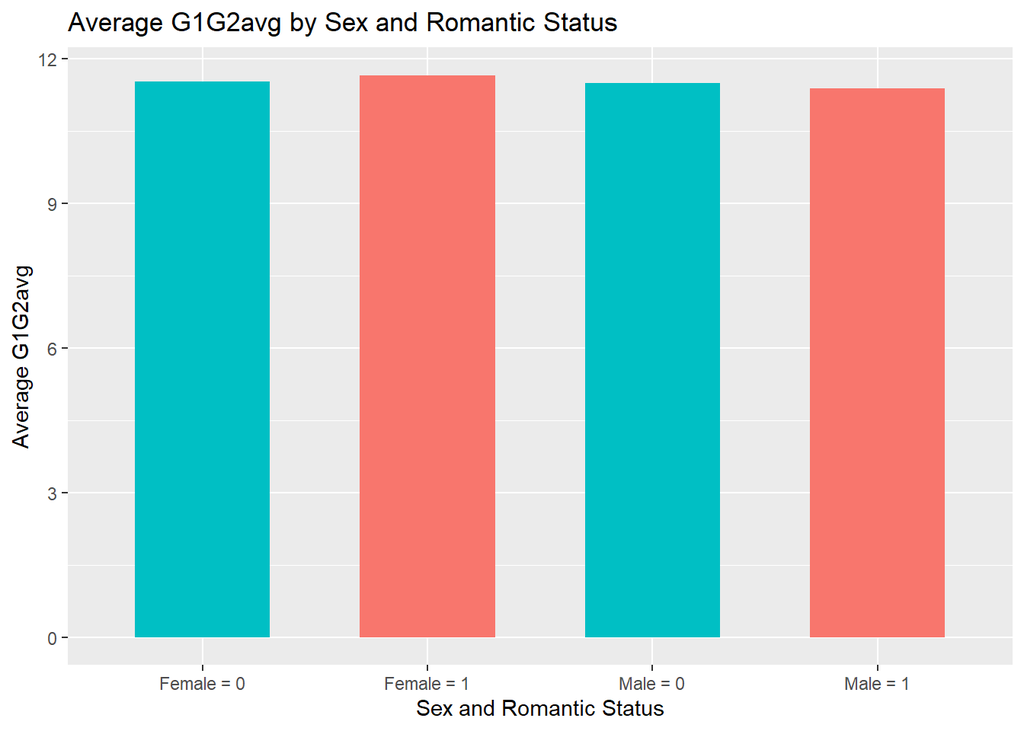

```r
# Calculate average of G1G2avg for each combination of romantic status and sex
avg_romantic_0_female <- mean(df_student[df_student$romantic == 0 & df_student$sex == "F", "G1G2avg"])
avg_romantic_0_male <- mean(df_student[df_student$romantic == 0 & df_student$sex == "M", "G1G2avg"])
avg_romantic_1_female <- mean(df_student[df_student$romantic == 1 & df_student$sex == "F", "G1G2avg"])
avg_romantic_1_male <- mean(df_student[df_student$romantic == 1 & df_student$sex == "M", "G1G2avg"])

# Create a bar plot
ggplot(data = NULL, aes(x = factor(c("Female = 0", "Male = 0", "Female = 1", "Male = 1")), y = c(avg_romantic_0_female, avg_romantic_0_male, avg_romantic_1_female, avg_romantic_1_male), fill = c("#C44E52", "#C44E52", "#4C72B0", "#4C72B0"))) +
  geom_bar(stat = "identity", width = 0.6) +
  xlab("Sex and Romantic Status") + ylab("Average G1G2avg") +
  ggtitle("Average G1G2avg by Sex and Romantic Status") +
  guides(fill = FALSE)
```

### Study Time

The findings suggest that students who study for a longer duration have a higher average score compared to those who study for a shorter duration.

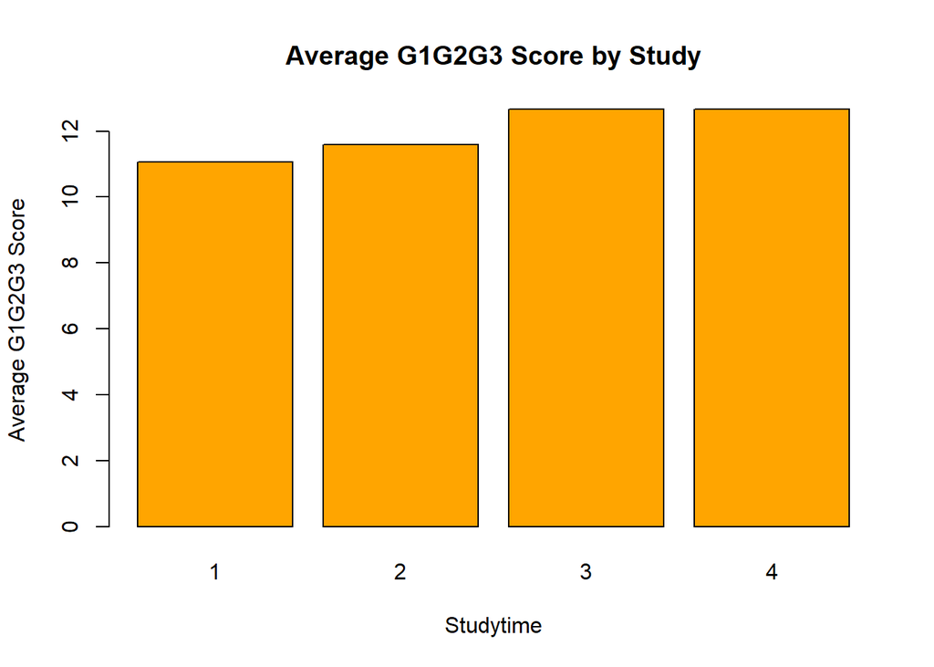

```r
# Calculate average of G1G2G3avg per studytime
study_avg <- aggregate(df_student$G1G2G3avg, by = list(df_student$studytime), FUN = mean)

# Create a bar graph
barplot(study_avg$x, names.arg = study_avg$Group.1, col = "orange", xlab = "Studytime",
        ylab = "Average G1G2G3 Score", main = "Average G1G2G3 Score by Study")
```

### Internet

The accessibility of the internet has become increasingly important in modern education, as it provides students with access to a vast array of learning materials that might otherwise be unavailable. It is widely recognized that the internet has the potential to enhance students’ educational experiences, but it is important to assess whether this potential is being fully realized. Therefore, it is necessary to examine whether the same positive results regarding internet accessibility and academic performance were obtained in the experiment.

The following graph indicates that the difference in academic performance between students with and without Internet access is negligible.

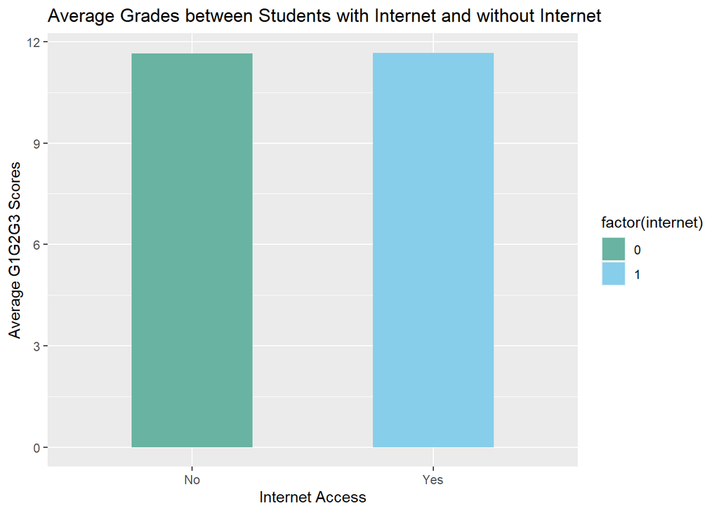

```r
df_student %>%
  group_by(internet) %>%
  summarise(G1G2G3avg_mean = mean(G1G2G3avg)) %>%
  ggplot(aes(x = factor(internet), y = G1G2G3avg_mean, fill = factor(internet))) +
  geom_bar(stat = "identity", width = 0.5) +
  scale_fill_manual(values = c("#69b3a2", "skyblue")) +
  labs(title = "Average Grades between Students with Internet and without Internet",
       x = "Internet Access",
       y = "Average G1G2G3 Scores") +
  scale_x_discrete(labels = c("No", "Yes"))
```

## Models

### Model 1 (Weighted least squares regression)

```r
#sum(is.na(df_student$internet))

#df_student <- na.omit(df_student)
#model <- lm(G3 ~ traveltime + romantic + internet + health + absences + G1 + G2, data = df_student)
#summary(model)

#write.csv(df_student, "C:/Users/SeungminSong/Downloads/621R/df_studentdata.csv", row.names = FALSE)
```

## Conclusion

In retrospect, I believe that the study would have been more robust if the data had been more precise and detailed. Investigating the underlying conditions that motivate students to study harder and how these factors affect their academic performance would have provided a more precise understanding of the relationship between external factors and academic success. While the survey data I used did provide useful insights, a more focused approach that delves into the specific motivators for studying and how these are related to academic outcomes could have yielded more comprehensive and sophisticated results.

Given more time, I would like to collect more extensive binary data and analyze it using binary regression models. This would allow me to examine the relationship between specific factors and academic performance in greater detail and to identify the factors that are most closely associated with academic success. By using more advanced statistical techniques, I could also explore the interplay between different external factors and their combined effects on academic performance. Such an analysis would be useful in designing targeted interventions to support students in their academic pursuits and improve educational outcomes.

Overall, this study provides a starting point for future research in the field of education and highlights the need for more comprehensive and detailed data to fully understand the complex relationship between external factors and academic success.